# Workflow for Ridgway’s Hawk Integrated Population Model

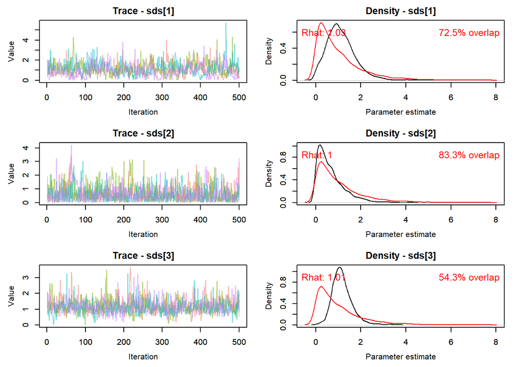

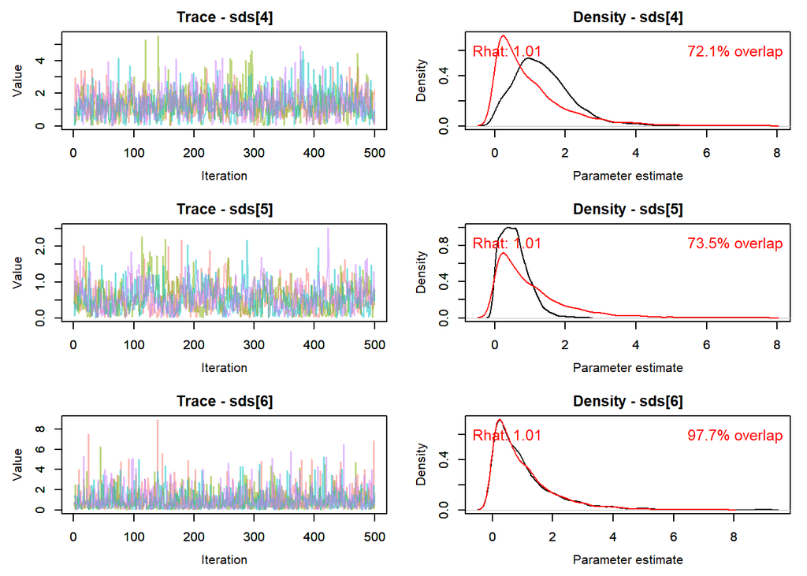

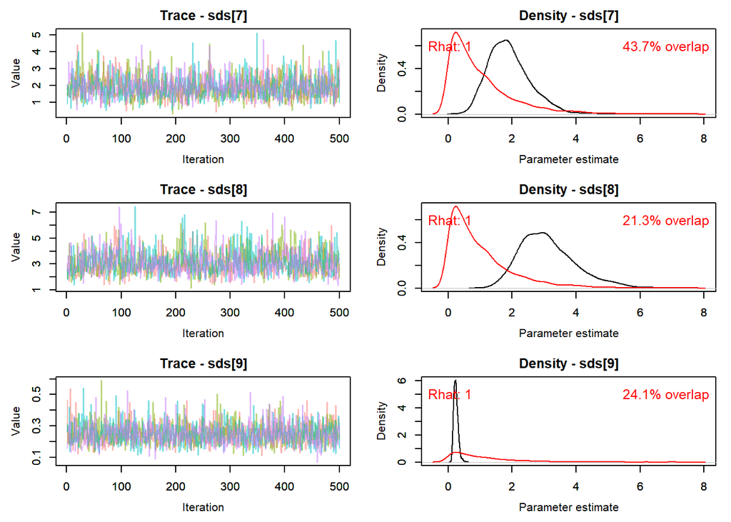

```r
MCMCtrace(out, pdf=FALSE, params= "sds", Rhat=TRUE, priors=rexp(20000, 1), post_zm=FALSE)
```

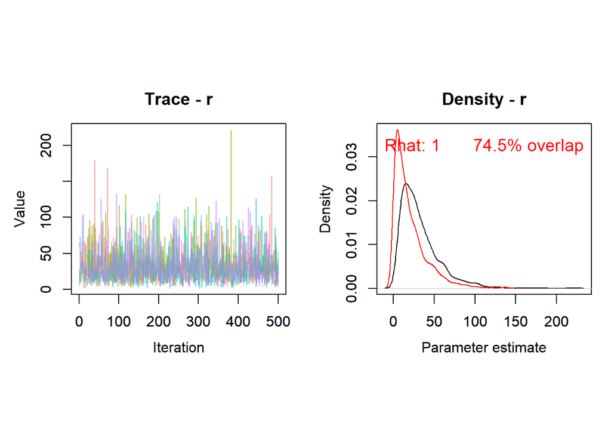

```r
MCMCtrace(out, pdf=FALSE, params= "r", Rhat=TRUE, priors=rexp(20000, 0.05), post_zm=FALSE)
```

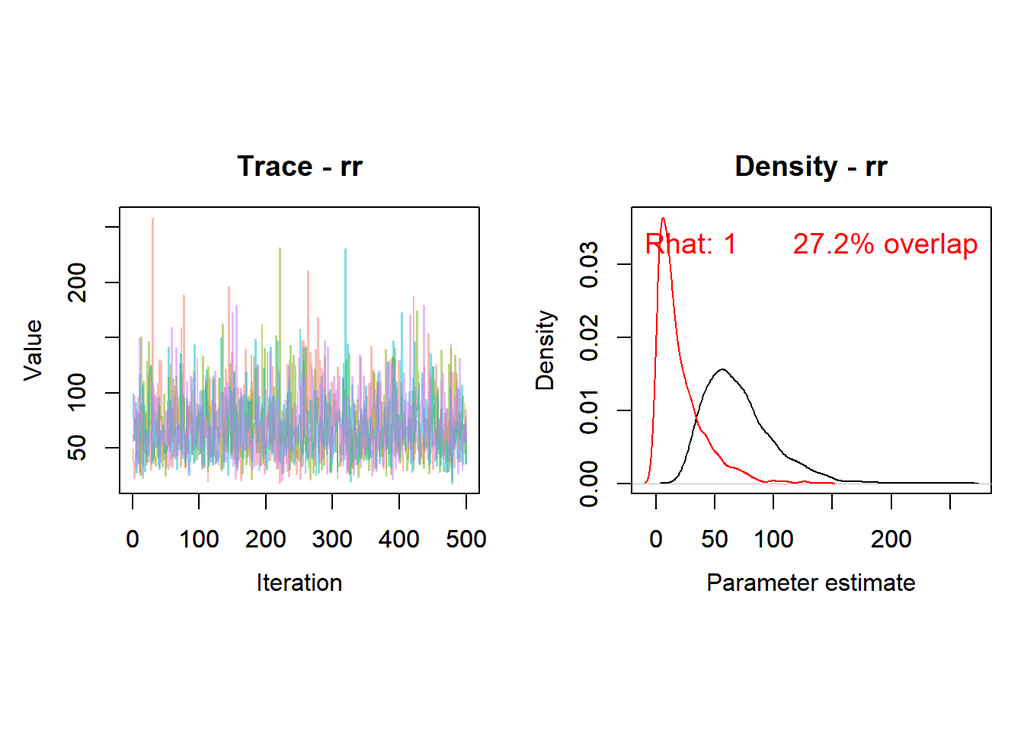

```r
MCMCtrace(out, pdf=FALSE, params= "rr", Rhat=TRUE, priors=rexp(20000, 0.05), post_zm=FALSE)
```

## 3.2 Demographics- Annual Averages

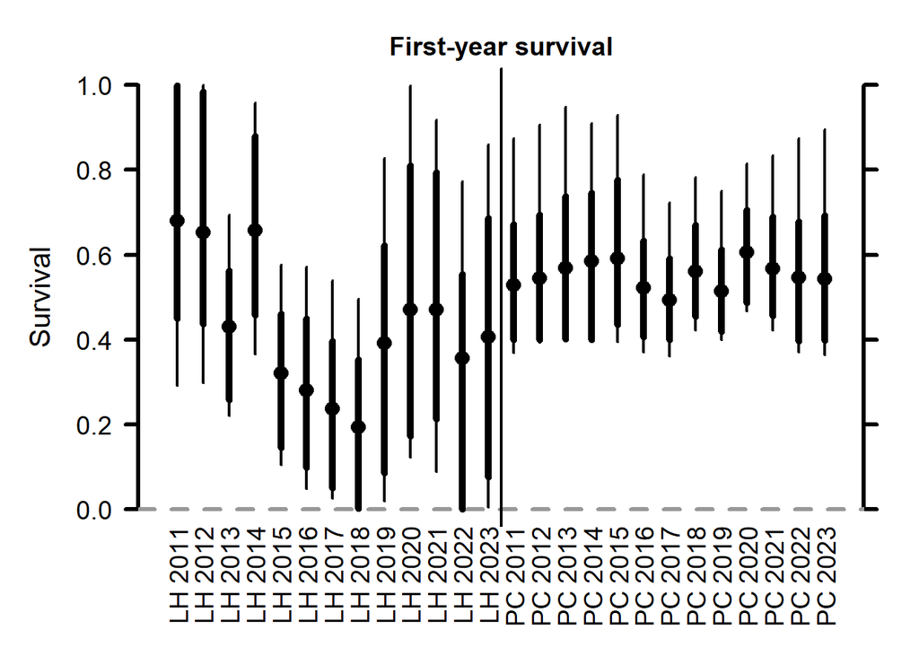

```r
# Demographics- Annual Averages
# Annual averages for integration into the population model
par(mfrow=c(1,1))
labs <- c(paste0("LH ",2011:2023), paste0("PC ",2011:2023))
plt(object=out, params="mn.phiFY", ylim=c(0,1),
    main="First-year survival", labels = labs,
    xlab = "Year", ylab= "Survival")
abline(v=13.5, lwd=2)
```

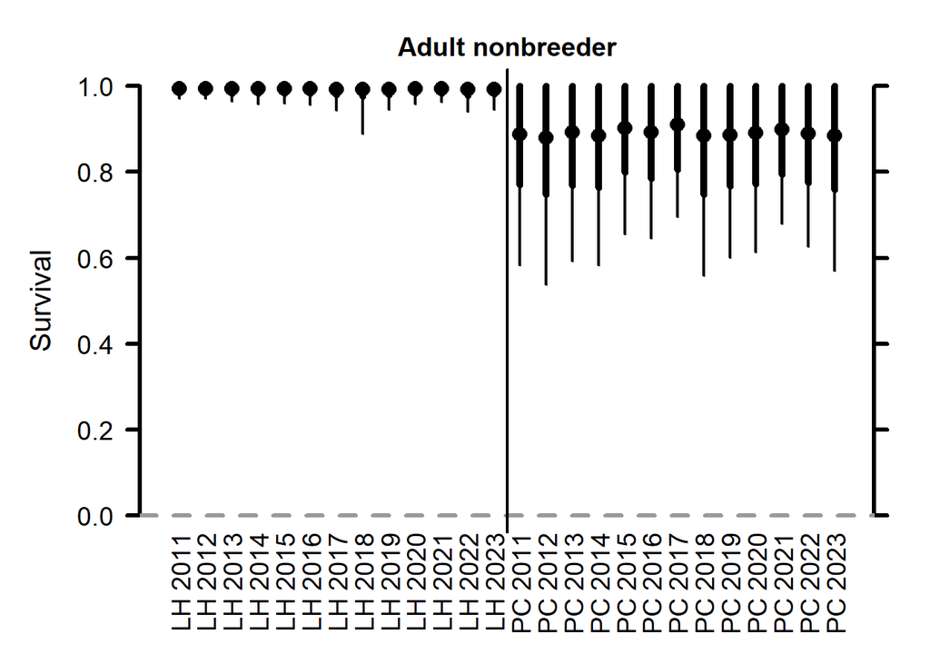

```r
plt(object=out, params="mn.phiA", ylim=c(0,1),
    main="Adult nonbreeder", labels = labs,
    xlab = "Year", ylab= "Survival")
abline(v=13.5, lwd=2)
```

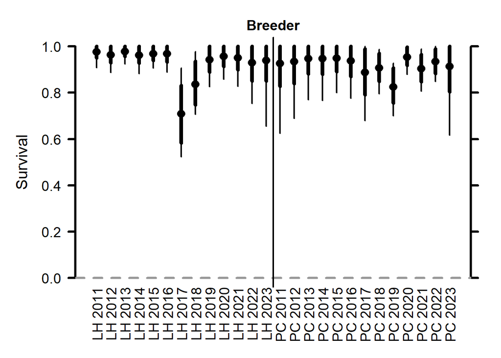

```r
plt(object=out, params="mn.phiB", ylim=c(0,1),
    main="Breeder", labels = labs,
    xlab = "Year", ylab= "Survival")
abline(v=13.5, lwd=2)
```

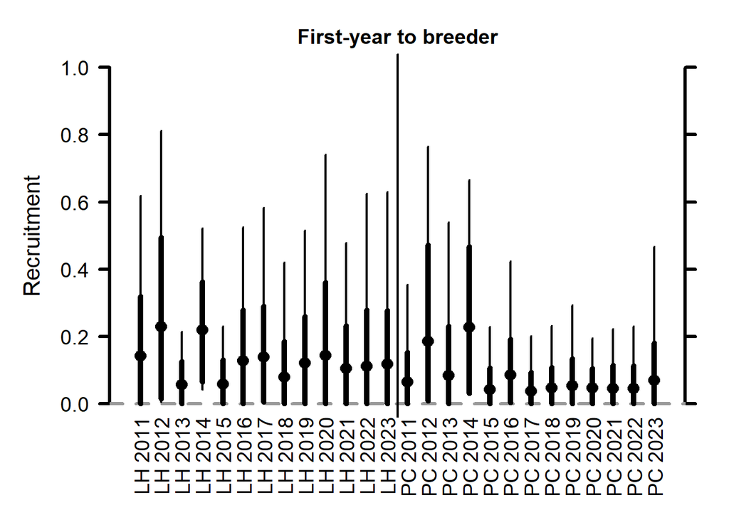

```r
plt(object=out, params="mn.psiFYB", ylim=c(0,1),
    main="First-year to breeder", labels = labs,
    xlab = "Year", ylab= "Recruitment")
abline(v=13.5, lwd=2)
```

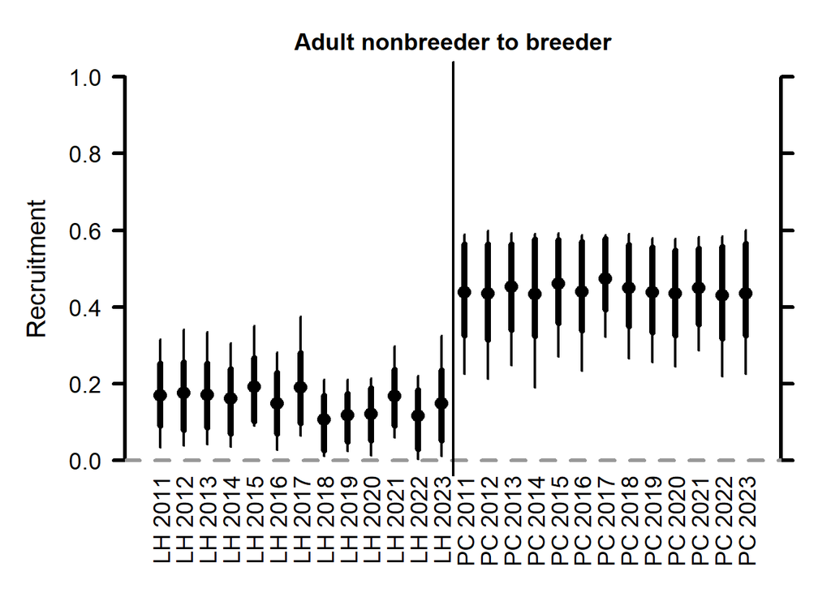

```r
plt(object=out, params="mn.psiAB", ylim=c(0,1),
    main="Adult nonbreeder to breeder", labels = labs,
    xlab = "Year", ylab= "Recruitment")
abline(v=13.5, lwd=2)
```

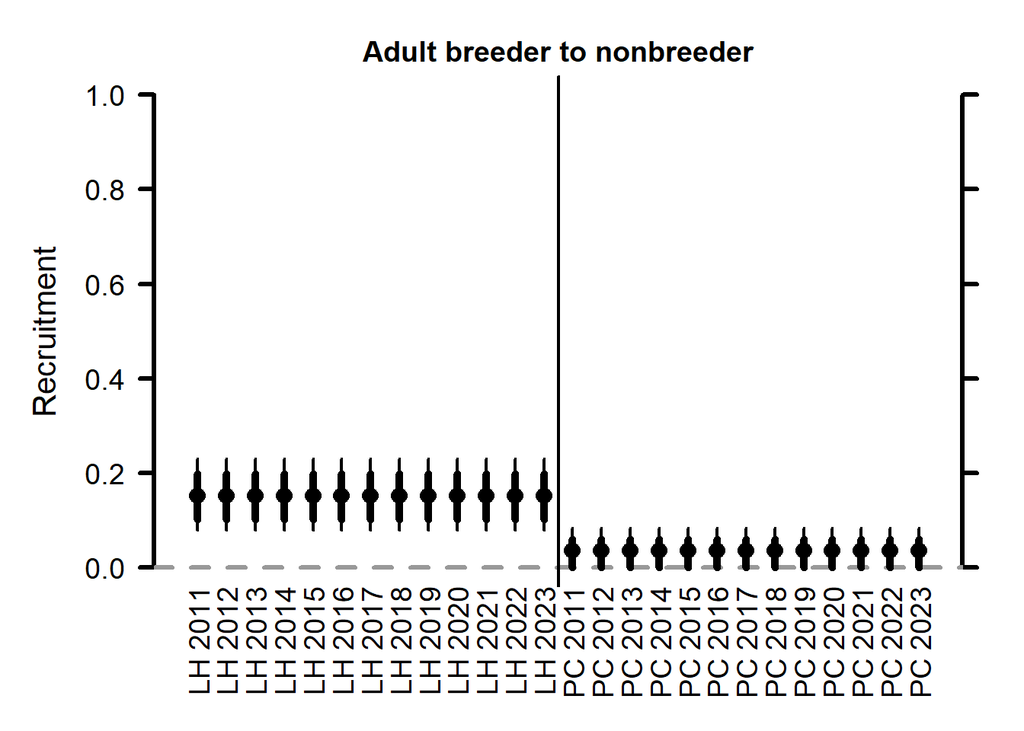

```r
plt(object=out, params="mn.psiBA", ylim=c(0,1),
    main="Adult breeder to nonbreeder", labels = labs,
    xlab = "Year", ylab= "Recruitment")
abline(v=13.5, lwd=2)
```

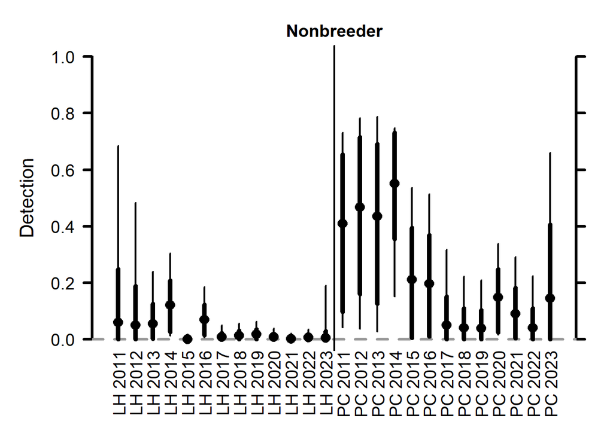

```r
plt(object=out, params="mn.pA", ylim=c(0,1),
    main="Nonbreeder", labels = labs,
    xlab = "Year", ylab= "Detection")
abline(v=13.5, lwd=2)
```

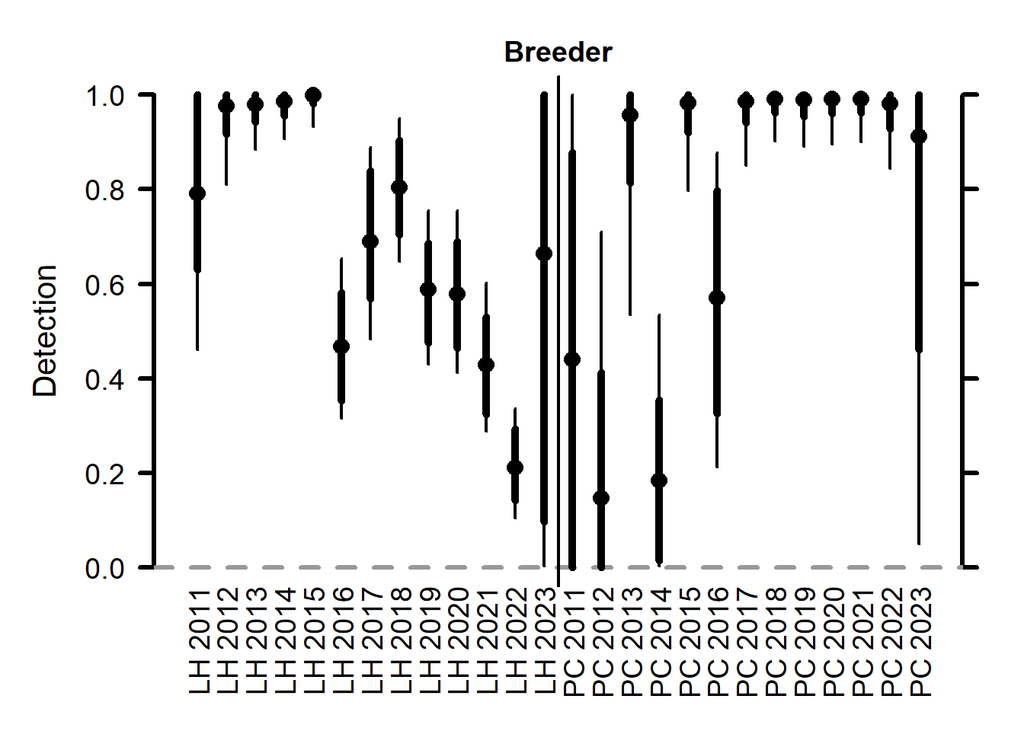

```r
plt(object=out, params="mn.pB", ylim=c(0,1),
    main="Breeder", labels = labs,
    xlab = "Year", ylab= "Detection")
abline(v=13.5, lwd=2)
```

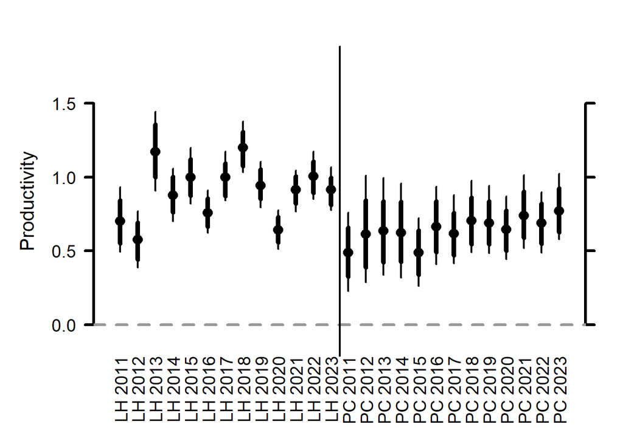

```r
plt(object=out, params="mn.prod",
    main="", labels=labs,
    xlab = "Year", ylab= "Productivity")
abline(v=13.5, lwd=2)
```

## 3.3 Abundance of Finer Population Segments

Plot model estimates of demographic rates. Life Stages are abbreviated as B = breeder, NB = nonbreeder, FY = first year. First-year abundance accounts for translocated birds.

Population dynamics are determined by transitions, These transitions between stages are abbreviated as the starting life stage to the final life stage. For example a first-year recruiting to a breeder would be abbreviated as “FY to B”. I’ll list them here for convenience:  
* “FY to NB” is first-year to nonbreeder.  
* “NB to NB” is nonbreeder adult to nonbreeder adult.  
* “B to NB” is a breeding adult to a nonbreeder adult.  
* “FY to B” is first-year to breeder.  
* “NB to B” is nonbreeder adult to breeder adult.  
* “B to B” is breeder adult to breeder adult.

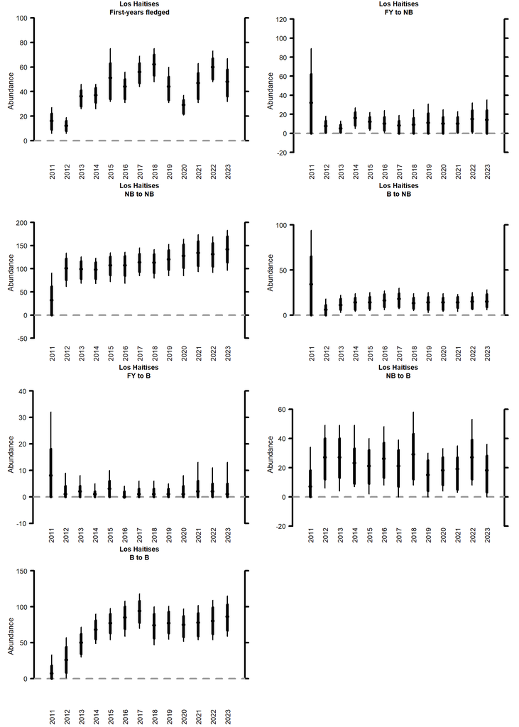

```r
# Finer population segments
par(mfrow=c(4,2))
plt(object=out,
    exact=TRUE, ISB=FALSE,
    params=paste0("N[", 1, ", ", 1:13, ", 1]"),
    main="Los Haitises\nFirst-years fledged",
    labels = 2011:2023,
    xlab = "Year", ylab= "Abundance")
plt(object=out,
    exact=TRUE, ISB=FALSE,
    params=paste0("N[", 2, ", ", 1:13, ", 1]"),
    main="Los Haitises\nFY to NB",
    labels = 2011:2023,
    xlab = "Year", ylab= "Abundance")
plt(object=out,
    exact=TRUE, ISB=FALSE,
    params=paste0("N[", 3, ", ", 1:13, ", 1]"),
    main="Los Haitises\nNB to NB",
    labels = 2011:2023,
    xlab = "Year", ylab= "Abundance")
plt(object=out,
    exact=TRUE, ISB=FALSE,
    params=paste0("N[", 4, ", ", 1:13, ", 1]"),
    main="Los Haitises\nB to NB",
    labels = 2011:2023,
    xlab = "Year", ylab= "Abundance")
plt(object=out,
    exact=TRUE, ISB=FALSE,
    params=paste0("N[", 5, ", ", 1:13, ", 1]"),
    main="Los Haitises\nFY to B",
    labels = 2011:2023,
    xlab = "Year", ylab= "Abundance")
plt(object=out,
    exact=TRUE, ISB=FALSE,
    params=paste0("N[", 6, ", ", 1:13, ", 1]"),
    main="Los Haitises\nNB to B",
    labels = 2011:2023,
    xlab = "Year", ylab= "Abundance")
plt(object=out,
    exact=TRUE, ISB=FALSE,
    params=paste0("N[", 7, ", ", 1:13, ", 1]"),
    main="Los Haitises\nB to B",
    labels = 2011:2023,
    xlab = "Year", ylab= "Abundance")


par(mfrow=c(4,2))
```

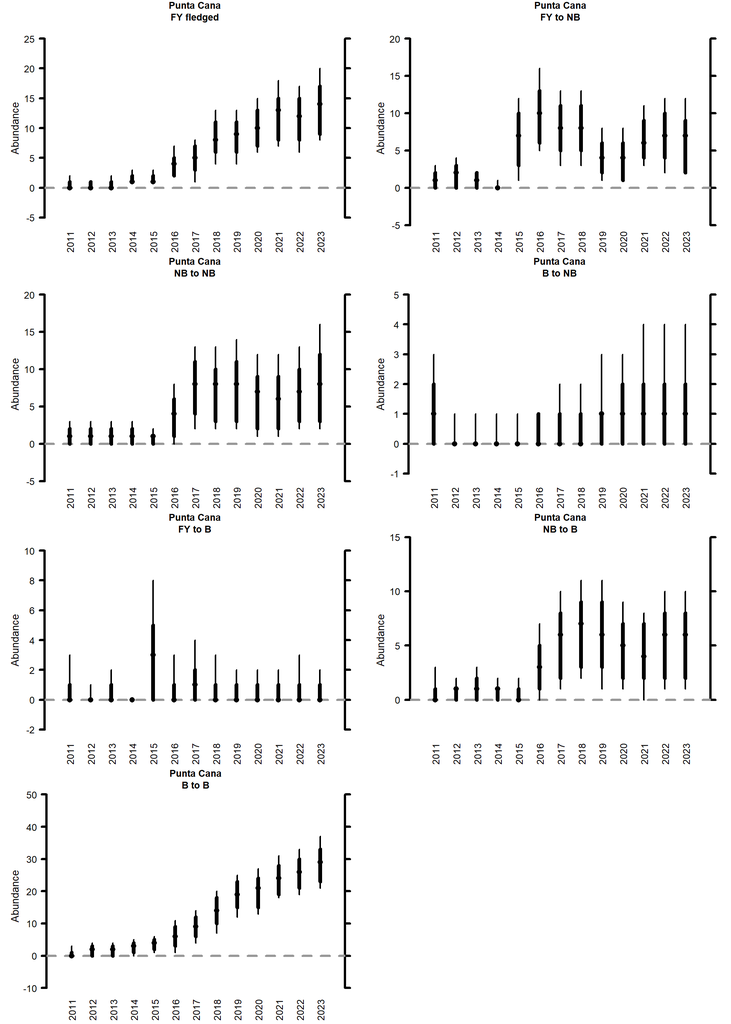

```r
plt(object=out,
    exact=TRUE, ISB=FALSE,
    params=paste0("N[", 1, ", ", 1:13, ", 2]"),
    main="Punta Cana\nFY fledged",
    labels = 2011:2023,
    xlab = "Year", ylab= "Abundance")
plt(object=out,
    exact=TRUE, ISB=FALSE,
    params=paste0("N[", 2, ", ", 1:13, ", 2]"),
    main="Punta Cana\nFY to NB",
    labels = 2011:2023,
    xlab = "Year", ylab= "Abundance")
plt(object=out,
    exact=TRUE, ISB=FALSE,
    params=paste0("N[", 3, ", ", 1:13, ", 2]"),
    main="Punta Cana\nNB to NB",
    labels = 2011:2023,
    xlab = "Year", ylab= "Abundance")
plt(object=out,
    exact=TRUE, ISB=FALSE,
    params=paste0("N[", 4, ", ", 1:13, ", 2]"),
    main="Punta Cana\nB to NB",
    labels = 2011:2023,
    xlab = "Year", ylab= "Abundance")
plt(object=out,
    exact=TRUE, ISB=FALSE,
    params=paste0("N[", 5, ", ", 1:13, ", 2]"),
    main="Punta Cana\nFY to B",
    labels = 2011:2023,
    xlab = "Year", ylab= "Abundance")
plt(object=out,
    exact=TRUE, ISB=FALSE,
    params=paste0("N[", 6, ", ", 1:13, ", 2]"),
    main="Punta Cana\nNB to B",
    labels = 2011:2023,
    xlab = "Year", ylab= "Abundance")
plt(object=out,
    exact=TRUE, ISB=FALSE,
    params=paste0("N[", 7, ", ", 1:13, ", 2]"),
    main="Punta Cana\nB to B",
    labels = 2011:2023,
    xlab = "Year", ylab= "Abundance")
```